# Andropogoneae Species

Michelle C. Stitzer

# *Urelytrum digitatum*

#### The assembly is haploid, and the genome is hexaploid. It has a haploid genome size of 4700 Mb, and has 30 haploid chromosomes.

### Species herbarium records

Herbarium records of *Urelytrum digitatum* from [AuBuchon-Elder et al 2022](https://nph.onlinelibrary.wiley.com/doi/full/10.1002/ppp3.10355) are plotted with black points, The sampled individual this genome was generated from is shown in a colored point. The green background shows the biogeographic ranges of all Andropogoneae species in [AuBuchon-Elder et al 2022](https://nph.onlinelibrary.wiley.com/doi/full/10.1002/ppp3.10355).

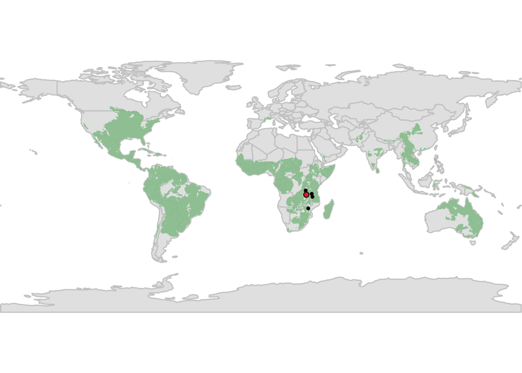

### Highlighted Figure 1

Figure 1 from the main text, with *Urelytrum digitatum* highlighted with colored points.

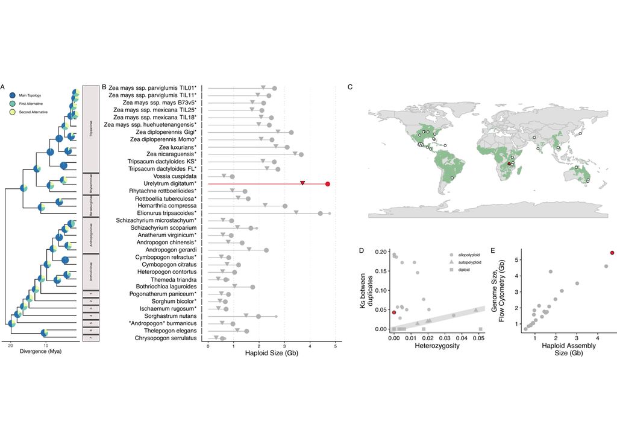

### Highlighted Figure 2

Figure 2 from the main text, with *Urelytrum digitatum* highlighted with colored points.

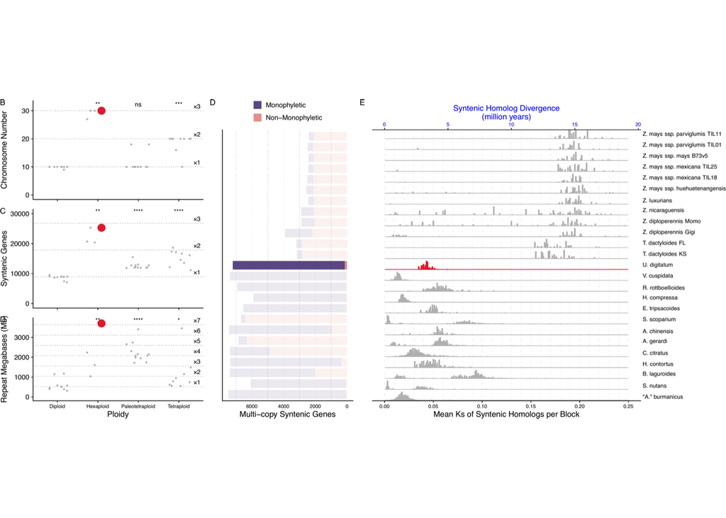

### Dotplot of *Urelytrum digitatum* vs. *Paspalum vaginatum*.

Like dotplots shown in Figure 3 of the main text, this shows syntenic blocks in *Urelytrum digitatum* along the y-axis, vs *P. vaginatum* on the x-axis. As Urelytrum digitatum is a hexaploid with a haploid, assembly, we expect 3 paths for any x-axis position.

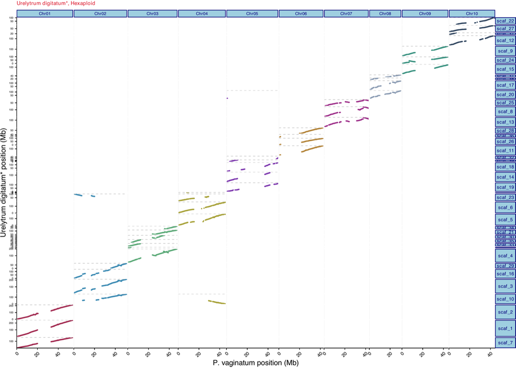

### Fractionation of *Urelytrum digitatum*

Like plots shown in Figure 4 of the main text, this shows proportion of retained genes in Urelytrum digitatum along the y-axis, vs P. vaginatum chromosomes on the x-axis. As *Urelytrum digitatum* is a hexaploid with a haploid, assembly, we expect 3 lines, one for each subgenome.

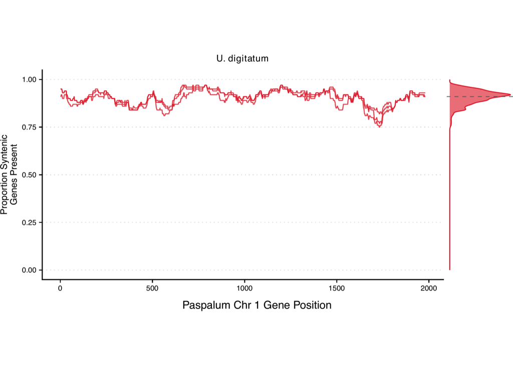